# Chapter 3 Modern Dive

## Question 3

It’s definitely unfair and uninformative to lump all non-rainbow-road tracks together. So let’s use one of the more powerful tricks in the book: the `group_by` + `summarize` combo. I cannot overstate how much you will use this in your daily life as a data analyst.

So take our dataset that includes only `Three Lap` times and group it by track, then use summarize to count how many different records have been established on each track.

```r
###--- Count number of observations (recods) by track
three_laps |>
  count(track) |>
  arrange(desc(n))
```

```
## # A tibble: 16 × 2
##    track                     n
##    <chr>                 <int>
##  1 Toad's Turnpike         124
##  2 Rainbow Road             99
##  3 Frappe Snowland          92
##  4 D.K.'s Jungle Parkway    86
##  5 Choco Mountain           84
##  6 Mario Raceway            82
##  7 Luigi Raceway            81
##  8 Royal Raceway            77
##  9 Yoshi Valley             74
## 10 Kalimari Desert          73
## 11 Sherbet Land             73
## 12 Wario Stadium            71
## 13 Koopa Troopa Beach       56
## 14 Banshee Boardwalk        55
## 15 Moo Moo Farm             44
## 16 Bowser's Castle          40
```

What’s the track that has had the most records established in it?

**Toad’s Turnpike is the track with most records.** > Hint: the verb `arrange()` might come in handy here.

## Question 4

We want to now if there are drivers who have multiple records at each track, and how many records they have. This will involve grouping by both driver and track.

```r
three_laps |>
  group_by(player, track) |>
  summarise(n = n()) |>
  arrange(desc(n))
```

```
## # A tibble: 306 × 3
## # Groups:   player [60]
##    player   track                     n
##    <chr>    <chr>                 <int>
##  1 Penev    Choco Mountain           26
##  2 Lacey    D.K.'s Jungle Parkway    24
##  3 abney317 Rainbow Road             21
##  4 MR       Toad's Turnpike          20
##  5 MR       Frappe Snowland          18
##  6 Penev    Toad's Turnpike          18
##  7 abney317 Kalimari Desert          16
##  8 MR       Sherbet Land             16
##  9 abney317 Choco Mountain           15
## 10 abney317 Toad's Turnpike          15
## # … with 296 more rows
```

Who is the player that has recorded the most records at any one track and what track was it?

**Penev at choco mountain with 26 records.**

## Question 5

We still haven’t looked at the times on each track. Tell me what the average time for each track is using `group_by` and `summarize`.

```r
three_laps |>
  group_by(track) |>
  summarise(av_time = mean(time)) |>
  arrange(desc(av_time))
```

```
## # A tibble: 16 × 2
##    track                 av_time
##    <chr>                   <dbl>
##  1 Rainbow Road            276.
##  2 Wario Stadium           214.
##  3 Royal Raceway           158.
##  4 Bowser's Castle         134.
##  5 Kalimari Desert         126.
##  6 Banshee Boardwalk       126.
##  7 Toad's Turnpike         122.
##  8 Sherbet Land            116.
##  9 Luigi Raceway           104.
## 10 D.K.'s Jungle Parkway   101.
## 11 Koopa Troopa Beach       96.6
## 12 Choco Mountain           95.2
## 13 Moo Moo Farm             88.4
## 14 Yoshi Valley             82.7
## 15 Mario Raceway            79.1
## 16 Frappe Snowland          77.1
```

What track has the highest average time?

**Rainbow Road had the highest average time.**

Let me introduce you to a cool trick. The `slice` function takes a certain number of rows inside of each group. For example we can pick the lowest time for each player like this:

```r
three_laps %>%
  group_by(player) %>%
  arrange(time) %>%
  slice(1) %>%
  head()
```

```
## # A tibble: 6 × 9
## # Groups:   player [6]
##   track      type    shortcut player  system_played date       time_period  time
##   <chr>      <chr>   <chr>    <chr>   <chr>         <date>     <chr>       <dbl>
## 1 Choco Mou… Three … Yes      ABE     NTSC          1997-06-01 1M 39.79S    99.8
## 2 Choco Mou… Three … Yes      abney3… NTSC          2021-02-03 17.29S       17.3
## 3 Yoshi Val… Three … Yes      Alex G  PAL           2010-11-27 33.39S       33.4
## 4 Frappe Sn… Three … Yes      Allen C NTSC          1997-10-31 28.22S       28.2
## 5 Wario Sta… Three … Yes      Ben M   PAL           2002-08-22 15.48S       15.5
## 6 Frappe Sn… Three … Yes      Booth   NTSC          1998-09-18 27.11S       27.1
## # … with 1 more variable: record_duration <dbl>
```

`head()` is just there to make sure that I only print a small amount of names.

Now, it’s your turn to show me the best time recorded on each track

The result you get using `group_by` and `arrange` contains a lot of information. So let’s use `select` so that your out displays only the name of the track and the lowest time recorded there.

```r
three_laps |>
  group_by(track) |>
  arrange(time) |>
  slice(1) |>
  head() |>
  select(track,time)
```

```
## # A tibble: 6 × 2
## # Groups:   track [6]
##   track                  time
##   <chr>                 <dbl>
## 1 Banshee Boardwalk     124.
## 2 Bowser's Castle       132
## 3 Choco Mountain         17.3
## 4 D.K.'s Jungle Parkway  21.4
## 5 Frappe Snowland        23.6
## 6 Kalimari Desert       122.
```

## Question 6

Let’s practice creating new variables. I am interested in the records that have held for longer than 100 days. Create a new variable that is a `1` if `record_duration` is higher than 100 or 0 otherwise.

```r
three_laps <-
  three_laps |>
  mutate(long_record = ifelse(record_duration > 100,1,0))
```

Now, grouping by player, tell me the total amount of long duration records each player holds. What player has the most long duration records?

```r
three_laps |>
  filter(long_record == 1) |>
  count(player) |>
  arrange(desc(n))
```

```
## # A tibble: 42 × 2
##    player       n
##    <chr>    <int>
##  1 MR          81
##  2 MJ          50
##  3 Penev       27
##  4 abney317    26
##  5 VAJ         26
##  6 Zwartjes    24
##  7 Lacey       23
##  8 Dan         21
##  9 Karlo       18
## 10 Booth       17
## # … with 32 more rows
```

**MR has the most long duration records.**

## Question 7

We will finish by strengthening our `joining` skills. We have another dataset called `drivers` that tells us where drivers are from.

Here’s how you can read it in.

```r
drivers <- read_csv("Data/drivers.csv")
```

Now use `left_join` to join `three_laps` and `drivers` together.

```r
three_laps <-
  three_laps |>
  left_join(drivers)
```

Now, plot a bar chart for how many records each country has.

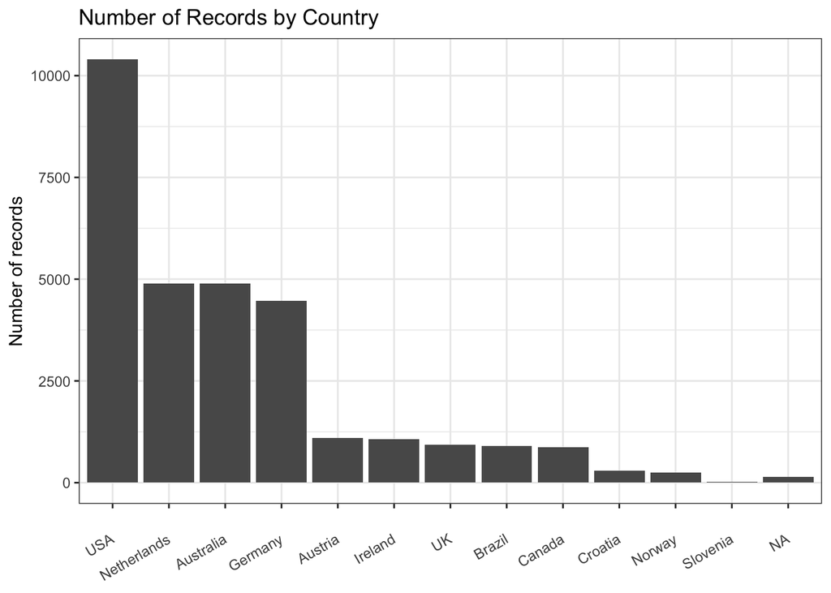

```r
three_laps |>
  count(nation) |>
  ggplot(aes(fct_rev(fct_reorder(nation,n)),n)) +
  geom_col() +
  labs(y = "Number of records",
       x = "",
       title = "Number of Records by Country") +
  theme_bw() +
  theme(axis.text.x = element_text(angle = 30, vjust = 0.5, hjust=1))
```